# Assignment 1: Clustering

### Using distance between Document Term Matrix

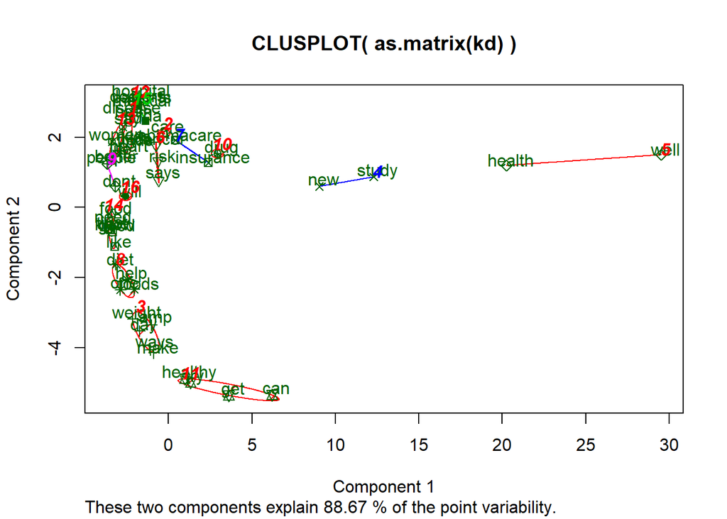

```r
dtm <- DocumentTermMatrix(tweetsData)
dtms <- removeSparseTerms(dtm, 0.15)
dic = findFreqTerms(dtms, lowfreq = 750)
ctrl <- list(dictionary = dic)
dtmd <- DocumentTermMatrix(tweetsData, control = ctrl)
kd <- dist(t(dtmd), method = "maximum")
kfit <- kmeans(kd, 16)
clusplot(as.matrix(kd), kfit$cluster, color = T, shade = T, labels = 2, lines = 5)
```

As we can observe there are a lot of clusters with two words and most of the words have been concentrated in one region. Naturally, the number of clusters can be reduced. We will now look for the value **k = 3**. Also, we will be using *maximum* metric to find the distance between the words.

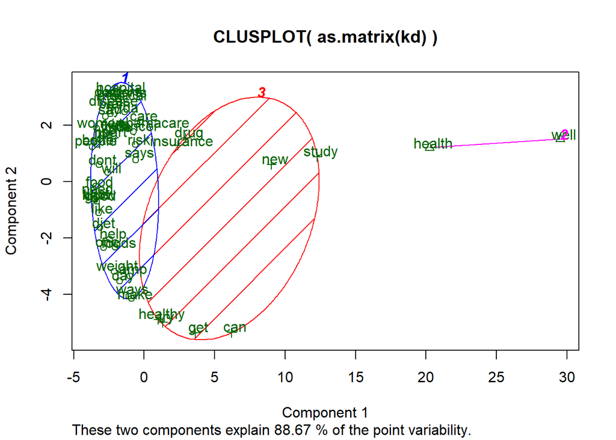

```r
dic = findFreqTerms(dtms, lowfreq = 750)
ctrl <- list(dictionary = dic)
dtmd <- DocumentTermMatrix(tweetsData, control = ctrl)
kd <- dist(t(dtmd), method = "maximum")
kfit <- kmeans(kd, 3)
clusplot(as.matrix(kd), kfit$cluster, color = T, shade = T, labels = 2, lines = 5)
```

As we can see the clusters are still not well defined. So we look for the *euclidean* distance.

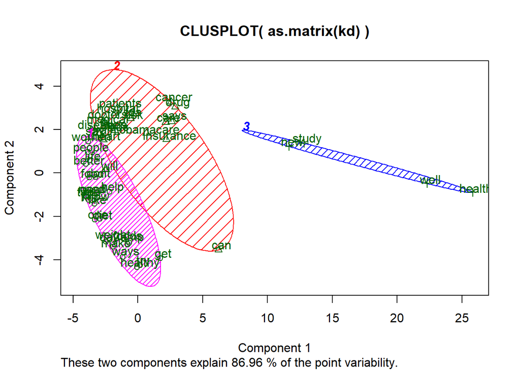

```r
dic = findFreqTerms(dtms, lowfreq = 750)
ctrl <- list(dictionary = dic)
dtmd <- DocumentTermMatrix(tweetsData, control = ctrl)
kd <- dist(t(dtmd), method = "euclidean")
kfit <- kmeans(kd, 3)
clusplot(as.matrix(kd), kfit$cluster, color = T, shade = T, labels = 2, lines = 5)
```

As can be seen from the above output, the *euclidean* distance does give us some well defined clusters. Now, we will use word embeddings to cluster the words. we will be using GLOVE algorithm for generating the word vectors.

Word embeddings work by generating word vectors from the text corpus which encode the context of those words and also the similarity between them. Here we will be training our own word vectors using the vocabulary in our tweets.

We will be using `text2vec` library to generate word embeddings. We will generate the vocabulary from our corpus and them train our word embeedings using that vocabulary. Initially we will keep the dimensions of the word vectors at *50*.

### Using distance between word vectors

```r
tokens <- space_tokenizer(tweetsData)
it = itoken(tokens, progressbar = FALSE)
vocab = create_vocabulary(it)
vocab = prune_vocabulary(vocab, term_count_min = 5L)
vectorizer = vocab_vectorizer(vocab)
tcm = create_tcm(it, vectorizer, skip_grams_window = 5L)
glove = GlobalVectors$new(word_vectors_size = 50, vocabulary = vocab, x_max = 10)
wv_main = glove$fit_transform(tcm, n_iter = 10, convergence_tol = 0.01)
```

```
## INFO [2019-02-08 00:00:09] 2019-02-08 00:00:09 - epoch 1, expected cost 0.0893
## INFO [2019-02-08 00:00:10] 2019-02-08 00:00:10 - epoch 2, expected cost 0.0538
## INFO [2019-02-08 00:00:10] 2019-02-08 00:00:10 - epoch 3, expected cost 0.0438
## INFO [2019-02-08 00:00:11] 2019-02-08 00:00:11 - epoch 4, expected cost 0.0379
## INFO [2019-02-08 00:00:12] 2019-02-08 00:00:12 - epoch 5, expected cost 0.0340
## INFO [2019-02-08 00:00:13] 2019-02-08 00:00:13 - epoch 6, expected cost 0.0311
## INFO [2019-02-08 00:00:14] 2019-02-08 00:00:14 - epoch 7, expected cost 0.0290
## INFO [2019-02-08 00:00:14] 2019-02-08 00:00:14 - epoch 8, expected cost 0.0274
## INFO [2019-02-08 00:00:15] 2019-02-08 00:00:15 - epoch 9, expected cost 0.0260
## INFO [2019-02-08 00:00:16] 2019-02-08 00:00:16 - epoch 10, expected cost 0.0249
```

```r
wv_context = glove$components
word_vectors = wv_main + t(wv_context)
```

The word vectors are now generated. we wil now cluster the most frequent words in our corpus. Here we will again use the *euclidean* distance to cluster the words.

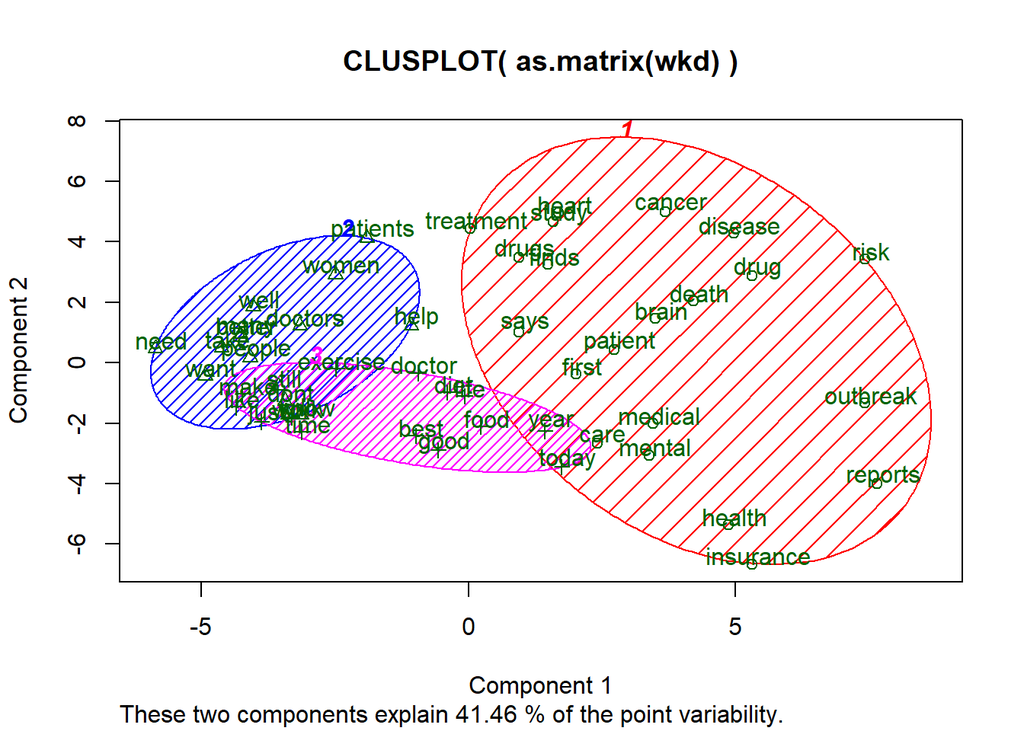

```r
newdtm <- TermDocumentMatrix(tweetsData, control = list(wordLengths = c(4, Inf)))
newdtms <- removeSparseTerms(newdtm, 0.05)
dic = findFreqTerms(newdtms, lowfreq = 600)

word_vectors <- word_vectors[dic,]
wkd <- dist(word_vectors, method = "euclidean")
wkfit <- kmeans(wkd, 3)
clusplot(as.matrix(wkd), wkfit$cluster, color = T, shade = T, labels = 2, lines = 5)
```

As we can see from the above output, word embeedings gives us a much better word clustering than the previous approach. We will now test for the *100* dimensions word embeddings..

```r
tokens <- space_tokenizer(tweetsData)
it = itoken(tokens, progressbar = FALSE)
vocab = create_vocabulary(it)
vocab = prune_vocabulary(vocab, term_count_min = 5L)
vectorizer = vocab_vectorizer(vocab)
tcm = create_tcm(it, vectorizer, skip_grams_window = 8L)

glove = GlobalVectors$new(word_vectors_size = 100, vocabulary = vocab, x_max = 10)
wv_main = glove$fit_transform(tcm, n_iter = 10, convergence_tol = 0.01)
```

```
## INFO [2019-02-08 00:00:32] 2019-02-08 00:00:32 - epoch 1, expected cost 0.0890
## INFO [2019-02-08 00:00:34] 2019-02-08 00:00:34 - epoch 2, expected cost 0.0463
## INFO [2019-02-08 00:00:36] 2019-02-08 00:00:36 - epoch 3, expected cost 0.0358
## INFO [2019-02-08 00:00:39] 2019-02-08 00:00:39 - epoch 4, expected cost 0.0304
## INFO [2019-02-08 00:00:41] 2019-02-08 00:00:41 - epoch 5, expected cost 0.0269
## INFO [2019-02-08 00:00:43] 2019-02-08 00:00:43 - epoch 6, expected cost 0.0244
## INFO [2019-02-08 00:00:45] 2019-02-08 00:00:45 - epoch 7, expected cost 0.0224
## INFO [2019-02-08 00:00:47] 2019-02-08 00:00:47 - epoch 8, expected cost 0.0209
## INFO [2019-02-08 00:00:49] 2019-02-08 00:00:49 - epoch 9, expected cost 0.0196
## INFO [2019-02-08 00:00:51] 2019-02-08 00:00:51 - epoch 10, expected cost 0.0186
```

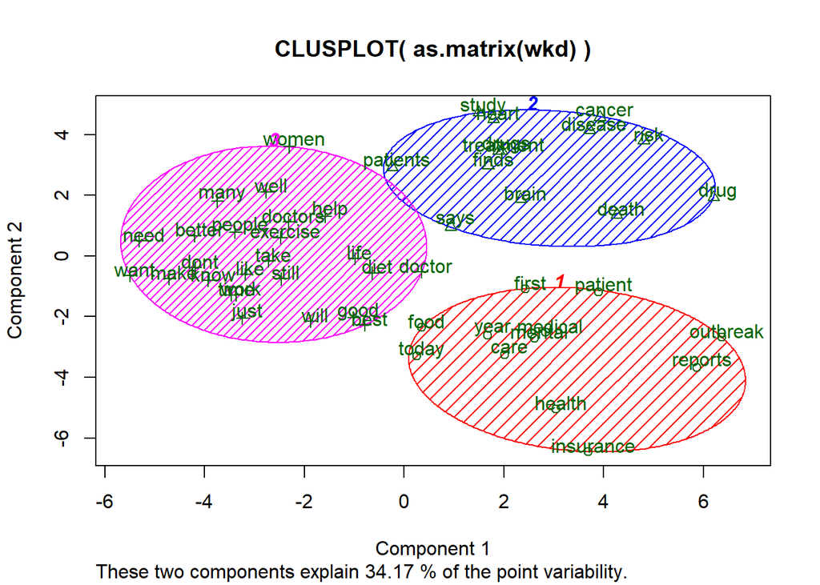

```r
wv_context = glove$components
word_vectors = wv_main + t(wv_context)

newdtm <- TermDocumentMatrix(tweetsData, control = list(wordLengths = c(4, Inf)))
newdtms <- removeSparseTerms(newdtm, 0.05)
dic = findFreqTerms(newdtms, lowfreq = 600)

word_vectors <- word_vectors[dic,]
wkd <- dist(word_vectors, method = "euclidean")
wkfit <- kmeans(wkd, 3)
clusplot(as.matrix(wkd), wkfit$cluster, color = T, shade = T, labels = 2, lines = 5)
```

We get a better output. So we will keep our word dimensions to *100*. Lastly, we will use *manhattan* distance metric to measure the distance between the words.

```r
tokens <- space_tokenizer(tweetsData)
it = itoken(tokens, progressbar = FALSE)
vocab = create_vocabulary(it)
vocab = prune_vocabulary(vocab, term_count_min = 5L)
vectorizer = vocab_vectorizer(vocab)
tcm = create_tcm(it, vectorizer, skip_grams_window = 8L)

glove = GlobalVectors$new(word_vectors_size = 100, vocabulary = vocab, x_max = 10)
wv_main = glove$fit_transform(tcm, n_iter = 10, convergence_tol = 0.01)
```

```
## INFO [2019-02-08 00:01:08] 2019-02-08 00:01:08 - epoch 1, expected cost 0.0891
## INFO [2019-02-08 00:01:10] 2019-02-08 00:01:10 - epoch 2, expected cost 0.0464
## INFO [2019-02-08 00:01:12] 2019-02-08 00:01:12 - epoch 3, expected cost 0.0358
## INFO [2019-02-08 00:01:14] 2019-02-08 00:01:14 - epoch 4, expected cost 0.0303
## INFO [2019-02-08 00:01:16] 2019-02-08 00:01:16 - epoch 5, expected cost 0.0269
## INFO [2019-02-08 00:01:19] 2019-02-08 00:01:19 - epoch 6, expected cost 0.0244
## INFO [2019-02-08 00:01:21] 2019-02-08 00:01:21 - epoch 7, expected cost 0.0224
## INFO [2019-02-08 00:01:23] 2019-02-08 00:01:23 - epoch 8, expected cost 0.0209
## INFO [2019-02-08 00:01:25] 2019-02-08 00:01:25 - epoch 9, expected cost 0.0197
## INFO [2019-02-08 00:01:27] 2019-02-08 00:01:27 - epoch 10, expected cost 0.0186
```

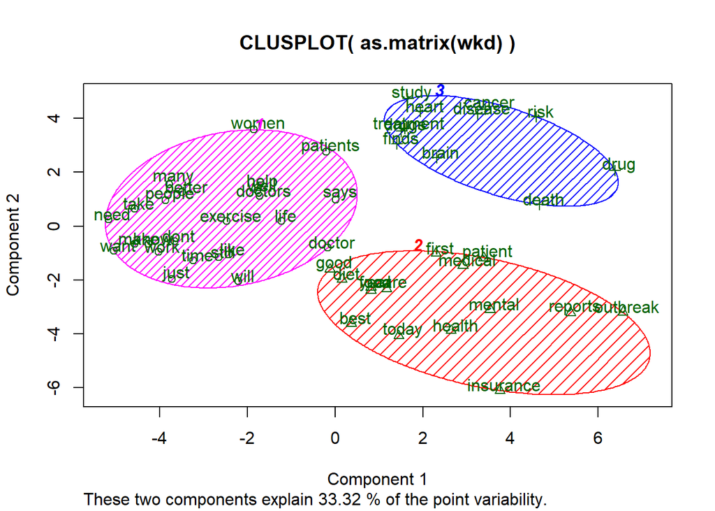

```r
wv_context = glove$components
word_vectors = wv_main + t(wv_context)

newdtm <- TermDocumentMatrix(tweetsData, control = list(wordLengths = c(4, Inf)))
newdtms <- removeSparseTerms(newdtm, 0.05)
dic = findFreqTerms(newdtms, lowfreq = 600)

word_vectors = wv_main + t(wv_context)
word_vectors <- word_vectors[dic,]
wkd <- dist(word_vectors, method = "manhattan")
wkfit <- kmeans(wkd, 3)
clusplot(as.matrix(wkd), wkfit$cluster, color = T, shade = T, labels = 2, lines = 5)
```

The manhattan distance gives us by far the most well defined cluster. So we accept this as our final cluster. We can also observe that the three clusters signify certain themes in the dataset.

The **Blue** cluster has most words with a negative theme such as *cancer*, *risk*, *death* and *disease* etc.

The **Red** cluster has words related to the health care such as *insurance*, *reports*, *medical*, *patient* etc.

Though some of the words in all the three clusters do not seem to relate with other words in the cluster such as *mental*, *outbreak*, *year*, *food* etc.